# Appendix

Models of retrieval in sentence comprehension

B. Nicenboim

S. Vasishth

January 10th, 2017

# 1 Appendix: K-fold cross validation

Since there were a number of $\hat{k} > 0.7$ indicating an unreliable calculation of $\hat{elpd}$ using PSIS-LOO for both models, we perform K-fold cross validation with $K=10$ following Vehtari, Gelman, and Gabry (2016).

```r
# Load R packages
library(ggplot2)
library(scales)
library(hexbin)
library(tidyr)
library(dplyr)
library(MASS)
library(rstan)
library(loo)
library(matrixStats)
rstan_options(auto_write = TRUE)
options(mc.cores = parallel::detectCores())
set.seed(42)
iter <- 2000
chains <- 3
```

We use the same data as before, but we create 10 lists, so that each list has 9/10 of the observations as training data and 1/10 of the observations as held out data. In order to avoid having very few or no observations of a given participant in the training set of some list, we group the data by participants before doing the split.

```r
load("dataNIG-SRC.Rda")
# save the order of the data frame
dexp$row <- as.numeric(as.character(row.names(dexp)))

if (!file.exists("ldata.Rda")) {
    # The following code prevents that there will be a fold without a
    # participant (or where a participant is underrepresented) (There might be a
    # simpler way) Assuming K = 10, the procedure is the following: 1) We
    # extract 1/10 of the data and save it in the list G with k = 1; 2) We
    # extract 1/9 of the remaining data and save it with k = 2; 3) We extract
    # 1/8 of the remaining data and save it with k = 3; 4) ...; 10) We extract
    # all the data the data and save it with k = 10
    K <- 10
    d <- dexp
    G <- list()
    for (i in 1:K) {
        G[[i]] <- sample_frac(group_by(d, participant), (1/(K + 1 - i)))
        G[[i]]$k <- i
        d <<- anti_join(d, G[[i]], by = c("participant", "item", "winner", "RT",
            "condition", "row"))
    }
    # We create a dataframe again:
    dK <- bind_rows(G)
    # We save the order of the dataframe
    dK <- dK[order(dK$row), ]
    ldata <- plyr::llply(1:K, function(i) {
        list(N_obs = nrow(dK), winner = dK$winner, RT = dK$RT, N_choices = max(dK$winner),
            subj = as.numeric(as.factor(dK$participant)), N_subj = length(unique(dK$participant)),
            item = as.numeric(as.factor(dK$item)), N_item = length(unique(dK$item)),
            holdout = ifelse(dK$k == i, 1, 0))
    })
    save(ldata, file = "ldata.Rda")
} else {
    load("ldata.Rda")
}

# All the folds include all the participant
for (k in 1:10) {
    print(paste0("Fold = ", k, "; N_subj = ", ldata[[k]]$N_subj, "; N_heldout = ",
        sum(ldata[[k]]$holdout)))
}
```

```
## [1] "Fold = 1; N_subj = 182; N_heldout = 364"
## [1] "Fold = 2; N_subj = 182; N_heldout = 364"
## [1] "Fold = 3; N_subj = 182; N_heldout = 364"
## [1] "Fold = 4; N_subj = 182; N_heldout = 364"
## [1] "Fold = 5; N_subj = 182; N_heldout = 364"
## [1] "Fold = 6; N_subj = 182; N_heldout = 363"
## [1] "Fold = 7; N_subj = 182; N_heldout = 364"
## [1] "Fold = 8; N_subj = 182; N_heldout = 355"
## [1] "Fold = 9; N_subj = 182; N_heldout = 364"
## [1] "Fold = 10; N_subj = 182; N_heldout = 322"
```

In order to apply K-fold cross validation, we modify the *Stan* models so that they increment the log-likelihood only when the data are not held out. We use the `generated quantities` section to calculate the pointwise likelihood for every observation, but we will later use only the likelihood of the held-out data for the calculation of $\hat{elpd}$. See also the files `activation-based_h_Kfold.stan` and `direct_access_h_Kfold.stan` for the details.

For the activation-based model:

```
(...)
model {
  (...)
  for (n in 1:N_obs) {
    if(holdout[n] == 0){
      vector[N_choices] alpha;
      real psi;
      alpha = alpha_0 + u[, subj[n]] + w[, item[n]];
      psi = exp(psi_0 + u_psi[subj[n]]);
      target += race(winner[n], RT[n], alpha, b, sigma, psi);
    }
  }
}
generated quantities {
  (...)
  vector[N_obs] log_lik;
  (...)
  for (n in 1:N_obs) {
    vector[N_choices] alpha;
    real psi;
    alpha = alpha_0 + u[, subj[n]] + w[, item[n]];
    psi = exp(psi_0 + u_psi[subj[n]]);
    log_lik[n] = race(winner[n], RT[n], alpha, b, sigma, psi);
  }
}
```

For the direct access model:

```
(...)
model {
 (...)
 for (n in 1:N_obs) {
    if(holdout[n] == 0){
      real mu_da;
      real mu_b;
      vector[N_choices] beta;
      real psi;
      mu_da = mu_da_0 + u_RT[1,subj[n]] + w_RT[1,item[n]];
      mu_b = mu_b_0 + u_RT[2,subj[n]] + w_RT[2,item[n]];
      beta = beta_0 + u[,subj[n]] + w[,item[n]];
      psi = exp(psi_0 + u_psi[subj[n]]);
      target += da(winner[n], RT[n], beta, P_b, mu_da, mu_b, sigma, psi);
    }
}
generated quantities {
(...)
  vector[N_obs] log_lik;
(...)
  for (n in 1:N_obs) {
    real mu_da;
    real mu_b;
    vector[N_choices] beta;
    real psi;
    vector[2] gen;
    mu_da = mu_da_0 + u_RT[1,subj[n]] + w_RT[1,item[n]];
    mu_b = mu_b_0 + u_RT[2,subj[n]] + w_RT[2,item[n]];
    beta = beta_0 + u[,subj[n]] + w[,item[n]];
    psi = exp(psi_0 + u_psi[subj[n]]);
    log_lik[n] = da(winner[n], RT[n], beta, P_b, mu_da, mu_b, sigma, psi);
  }
}
```

Then we use the following function to parallelize the 10 runs of both models:

```r
# The following function can run all the chains of all the folds of the
# model in parallel:

stan_kfold <- function(file, list_of_datas, chains, cores, ...) {
    library(pbmcapply)
    badRhat <- 1.1
    K <- length(list_of_datas)
    model <- stan_model(file = file)
    # First parallelize all chains:
    sflist <- pbmclapply(1:(K * chains), mc.cores = cores, function(i) {
        # Fold number:
        k <- ((i + 1)/chains)
        s <- sampling(model, data = list_of_datas[[k]], chains = 1, chain_id = i,
            ...)
        return(s)
    })
    # Then merge the K * chains to create K stanfits:
    stanfit <- list()
    for (k in 1:K) {
        inchains <- (chains * k - 2):(chains * k)
        # Merge `chains` of each fold
        stanfit[[k]] <- sflist2stanfit(sflist[inchains])
    }
    return(stanfit)
}
```

We run the models and extract the log-likelihood evaluated at the posterior simulations of the parameter values:

```r
# Wrapper function to extract the log_lik of the held-out data, given a list
# of stanfits, and a list which indicates with 1 and 0 whether the
# observation was held out or not:
extract_log_lik_K <- function(list_of_stanfits, list_of_holdout, ...) {
    K <- length(list_of_stanfits)
    list_of_log_liks <- plyr::llply(1:K, function(k) {
        extract_log_lik(list_of_stanfits[[k]], ...)
    })
    # `log_lik_heldout` will include the loglike of all the held out data of all
    # the folds.  We define `log_lik_heldout` as a (samples x N_obs) matrix
    # (similar to each log_lik matrix)
    log_lik_heldout <- list_of_log_liks[[1]] * NA
    for (k in 1:K) {
        log_lik <- list_of_log_liks[[k]]
        samples <- dim(log_lik)[1]
        N_obs <- dim(log_lik)[2]
        # This is a matrix with the same size as log_lik_heldout with 1 if the data
        # was held out in the fold k
        heldout <- matrix(rep(list_of_holdout[[k]], each = samples), nrow = samples)
        # Sanity check that the previous log_lik is not being overwritten:
        if (any(!is.na(log_lik_heldout[heldout == 1]))) {
            warning("Heldout log_lik has been overwritten!!!!")
        }
        # We save here the log_lik of the fold k in the matrix:
        log_lik_heldout[heldout == 1] <- log_lik[heldout == 1]
    }
    return(log_lik_heldout)
}

# We apply the function to both models:
if (!file.exists("log_lik_ab.Rda")) {
    # We run all the chains of all the folds of the activation-based model in
    # parallel: (We are using 30 cores of a server)
    ab10Kfits <- stan_kfold("activation-based_h_Kfold.stan", list_of_datas = ldata,
        chains = 3, cores = 30, seed = 42, iter = iter)
    holdout <- lapply(ldata, "[[", "holdout")
    # We extract all the held_out log_lik of all the folds
    log_lik_ab <- extract_log_lik_K(ab10Kfits, holdout, "log_lik")
    save(log_lik_ab, file = "log_lik_ab.Rda")
} else {
    load("log_lik_ab.Rda")
}

if (!file.exists("log_lik_da.Rda")) {
    # We run all the chains of all the folds of the direct access model in
    # parallel:
    da10Kfits <- stan_kfold("direct_access_h_Kfold.stan", list_of_datas = ldata,
        chains = 3, cores = 30, seed = 42, iter = iter)
    holdout <- lapply(ldata, "[[", "holdout")
    # We extract all the held_out log_lik of all the folds
    log_lik_da <- extract_log_lik_K(da10Kfits, holdout, "log_lik")
    save(log_lik_da, file = "log_lik_da.Rda")
} else {
    load("log_lik_da.Rda")
}
```

The following function is an adaptation of `loo` function from `R` package `loo` to calculate pointwise and total $\hat{elpd}$ of K-fold cross validation:

```r
kfold <- function(log_lik_heldout) {
    library(matrixStats)
    logColMeansExp <- function(x) {
        # should be more stable than log(colMeans(exp(x)))
        S <- nrow(x)
        colLogSumExps(x) - log(S)
    }
    # See equation (20) of @VehtariEtAl2016
    pointwise <- matrix(logColMeansExp(log_lik_heldout), ncol = 1)
    colnames(pointwise) <- "elpd"
    # See equation (21) of @VehtariEtAl2016
    elpd_kfold <- sum(pointwise)
    se_elpd_kfold <- sqrt(ncol(log_lik_heldout) * var(pointwise))
    out <- list(pointwise = pointwise, elpd_kfold = elpd_kfold, se_elpd_kfold = se_elpd_kfold)
    structure(out, class = "loo")
}
```

We can now repeat the same analysis using K-fold cross validation instead of PSIS-LOO:

```r
(kfold_ab <- kfold(log_lik_ab))
```

```
## Computed from  log-likelihood matrix
##
##            Estimate   SE
## elpd_kfold -26582.0 94.8
```

```r
(kfold_da <- kfold(log_lik_da))
```

```
## Computed from  log-likelihood matrix
##
##            Estimate   SE
## elpd_kfold -26467.0 94.9
```

Comparing the models on K-fold cross validation reveals also an estimated difference in $\hat{elpd}$ in favor of the direct access model in comparison with the activation-based model:

```r
(kfold_comparison <- compare(kfold_ab, kfold_da))
```

```
## elpd_diff        se
##     115.0      23.5
```

We compare models in their $\hat{elpd}$, point by point below according to K-fold cross validation calcualtion. These graphs are very similar to the ones using $\hat{elpd}$ calculated with PSIS-LOO. (The code producing the graphs is available in the Rmd file.)

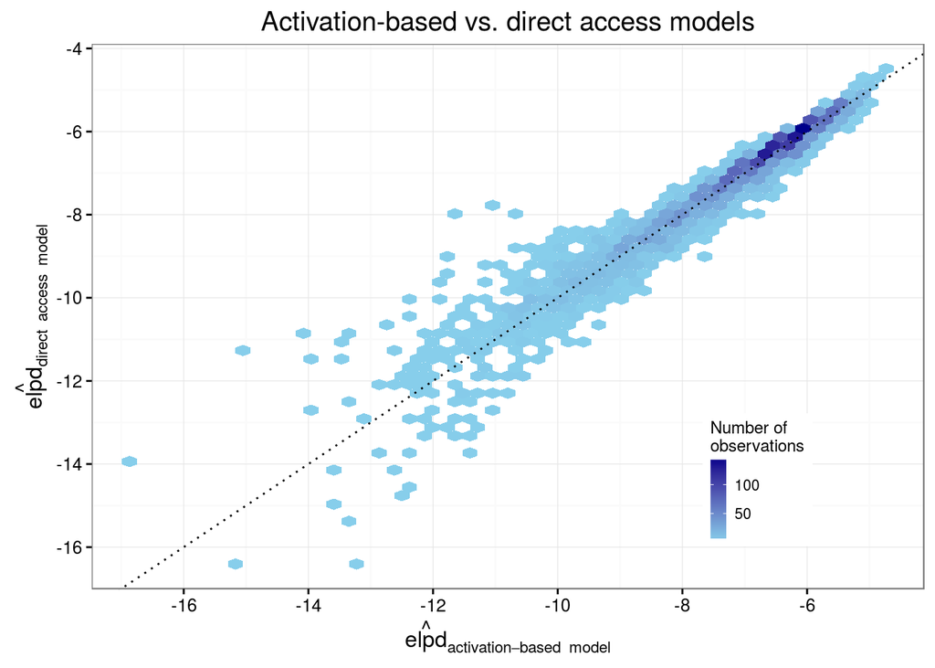

Figure 1. Comparison of the activation-based and direct access models in terms of their predictive accuracy for each observation. Each axis shows the expected pointwise contributions to k-fold cross validation for each model ($\hat{elpd}$ stands for the expected log pointwise predictive density of each observation). Higher (or less negative) values of $\hat{elpd}$ indicate a better fit. Darker cells represent a higher concentration of observations with a given fit.

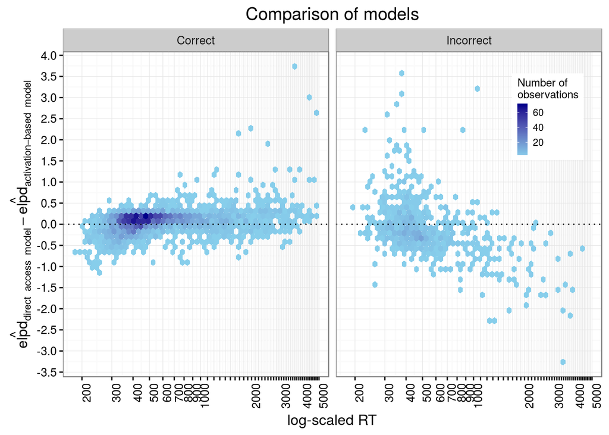

Figure 2. Comparison of the activation-based and direct access models in terms of their predictive accuracy for each observation depending on its log-transformed reading time (x-axis) and accuracy (left panel showing correct responses, and the right panel showing any of the possible incorrect responses). The y-axis shows the difference between the expected pointwise contributions to k-fold cross validation for each model ($\hat{elpd}$ stands for the expected log pointwise predictive density of each observation); that is, positive values represent an advantage for the direct access model while negative values represent an advantage for the activation-based model. Darker cells represent a higher concentration of observations with a given fit.

# 2 References

Vehtari, Aki, Andrew Gelman, and Jonah Gabry. 2016. “Practical Bayesian Model Evaluation Using Leave-One-Out Cross-Validation and WAIC.” *Statistics and Computing*.